# Create a PCIBEX experiment from (semi-)scratch

Author

[Utku Turk](https://www.utkuturk.com)

# 1 Introduction

We have our experimental items and filler items as `.csv` files. We also have installed VS Code and created a github account. Now, all we need to do is to create an experiment file. We will cover these steps:

- Initiate a git repo
- Sync local git and web git
- Create necessary folders for PCIbex
- Create the experiment file
- Sync everything with PCIbex

# 2 Repo Initiation

First, check if you have git installed in your computer. Open your terminal app and type the following code. If Git is installed, you’ll see the version number.

```bash
git --version
```

If Git is not installed, go to this link and install it: https://git-scm.com/downloads

After installation, again in your terminal configure your name and email that you use for github. Do not forget to change my name and email.

```bash
git config --global user.name "Utku Turk"
git config --global user.email "utkuturk@umd.edu"
```

Now that, we have this figured out. Let’s create a folder. First type `cd` and press enter in your terminal to reset your relative place in your files.

Now, write the following code in your terminal. The following code creates a new folder (`mkdir`), goes to that folder’s destination (`cd`), and initiates a git repo (`git init`).

```bash
mkdir 640_exp
cd 640_exp
git init
```

We also want to initiate 4 more folders for PCIbex: chunk_includes, css_includes, data_includes, js_includes. We will mainly dwell in chunk_includes and data_includes. Chunk one will have our resource files like the csv files. Data one will include our experimental code! One can also play with css and js ones which edits stuff more integral to how PCIbex works.

```bash
mkdir chunk_includes css_includes data_includes js_includes
```

Finally, we want to create a README file. This is going to include whatever information we want. I usually use it to keep track of what the repo is about and what the folders include.

```bash
touch README.md
```

Now, we are ready to push our first repo online. Do not forget to change my username to your own. **Before this, go to github website and create new repo with the name of 640_exp!**

```bash
git add .
git commit -m "first commit"
git remote add "origin" git@github.com:utkuturk/640_exp.git
git push -u origin main
```

Now, you should be able to go and check your repo: www.github.com/utkuturk/640_exp.

# 3 Experiment File

## 3.1 Creating the Experiment File

First thing we want to do is to create an experiment file. Again in your terminal, write this code:

```bash
touch data_includes/main.js
```

From now on, we will work in VS Code/Positron. In your terminal, type the following:

```bash
code ~/640_exp
```

If you want to work on Positron, first open Positron, then press CMD + SHIFT + P and type `positron path`, you should see Shell Command: Install ‘positron’ command in Path.

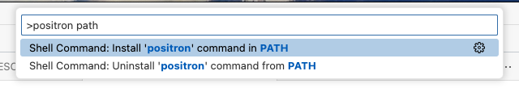

Then, you can replace `code` with `positron`.

```bash
positron ~/640_exp
```

## 3.2 Content of `main.js`

Our experiment code will have some subparts. Can you do without them? Of course, but we won’t.

- PCIbex relevant set up
- Experiment Constants
- CSS Constants
- Functions
- Metadata
- Sequence
- Pages
  - Consent
  - Instructions
  - Practice
  - Are you ready to start the experiment?
  - Break
  - End of the experiment
- Trial Template

Normally, intros give you very simple experiments, here we will try to do a maximal design.

### 3.2.1 PCIbex Set-up

First, we will start 3 lines of code which establishes three important things in the experiment: (i) we do not have to write PennController all the time, (ii) people do not see a debug menu, (iii) we iterate through Latin-square design.

```
main.js
```

```javascript
// Set-up
PennController.ResetPrefix(null);
DebugOff();
SetCounter("setcounter");
```

### 3.2.2 Constants

During the experiment, we will have a lot of decisions to make. The font size of the header, how much time should it take to go to the next element? How much time the cross should stay on the screen? We can either specify these again and again, or we can specify it only once here and then use the special name. For now, I am putting down very simple stuff, but one can go ahead and populate it with as many stuff as needed.

```
main.js
```

```javascript
// Experiment Constants
const cross_time = 450;
const rsvp_time = 450;
const rsvp_int_time = 100;
const post_rsvp_time = 100;
const proceed_timeout = 3000;
const header_font_size = "36";
const body_font_size = "18";
const fname_exp = "stim_exp.csv";
const fname_filler = "stim_filler.csv";
```

### 3.2.3 CSS Constants

I usually try to have a very strict visual convergence in how experiment will look like. And, similar to constants above, if one does not put them as a constant in the beginning, it is very likely that one will fail to remember change all of them if they need to change it at one point.

```
main.js
```

```javascript
// CSS Constants
var body_css = {
    "text-align": "center",
    margin: "0 auto",
    "font-size": body_font_size
};

var header_css = {
    "text-align": "center",
    margin: "0 auto",
    "font-size": header_font_size
};

var button_css = {
    "background-color": "#E03A3E",
    color: "white",
    "font-size": "1.25em",
    padding: "0.5em",
    "border-radius": "0.25em",
    margin: "0 auto",
    "text-align": "center",
    border: "none", // Remove default button border
    display: "block", // To center the button
};
```

### 3.2.4 Functions

PCIbex can do a lot of stuff, but some of the stuff are not readily implemented. One such thing is the ability to insert breaks given a set of trials. We want our trials in the experiment to be randomized. We also do want to include a break every now and then. One solution that many people unfortunately use is to create a pseudo-randomization. It is sometimes very helpful for your own experiment design. But, we do not want that. So, here’s a function that will help us with that.

I have found this code in the [PCIbex forum](https://www.pcibex.net/forums/). I suggest you to ask any questions you there, and of course, search your question first.

```
main.js
```

```javascript
// Functions
//for inserting breaks
function SepWithN(sep, main, n) {
  this.args = [sep, main];

  this.run = function (arrays) {
    assert(
      arrays.length == 2,
      "Wrong number of arguments (or bad argument) to SepWithN"
    );
    assert(parseInt(n) > 0, "N must be a positive number");
    let sep = arrays[0];
    let main = arrays[1];

    if (main.length <= 1) return main;
    else {
      let newArray = [];
      while (main.length) {
        for (let i = 0; i < n && main.length > 0; i++)
          newArray.push(main.pop());
        for (let j = 0; j < sep.length && main.length > 0; ++j)
          newArray.push(sep[j]);
      }
      return newArray;
    }
  };
};
function sepWithN(sep, main, n) {
  return new SepWithN(sep, main, n);
};
```

### 3.2.5 Metadata

This part is usually a housekeeping part. If you do not do this, nothing bad will happen, and usually you can circumvent any problem with writing more R code. But, if you correctly do this part, data analysis will be a lot more easier.

Instead of dealing with column names later, one can define them in the PCIbex.

```
main.js
```

```javascript
// Metadata
Header(
  newVar("itemnum").global(),
  newVar("type").global(),
  newVar("condition").global(),
  newVar("text").global(),
  newVar("RT").global()
)
  .log("PROLIFIC_ID", GetURLParameter("id"))
  .log("itemnum", getVar("itemnum"))
  .log("type", getVar("type"))
  .log("condition", getVar("condition"))
  .log("text", getVar("text"))
  .log("RT", getVar("RT"));
```

### 3.2.6 Sequence

This part is going to determine in which the order experiments’ part will be run. All the constants, variables, functions, header, ResetPrefix, and DebugOff will be run immediately. However, the rest will not, including setcounter!

A simple sequence can be as small as the following:

```javascript
Sequence("instructions", randomize("exp"))
```

However, as you can see, this lacks a lot of the stuff we want. Here’s our hefty sequence:

```
main.js
```

```javascript
Sequence("setcounter", "consent", "instructions", randomize("practice"), "exp-start", sepWithN("break", rshuffle("exp", "filler"), 15), "send_results", "bye")
```

### 3.2.7 Pages

Now, it is about the parts that will participants will see. Elements within PCIbex follows a very simple pattern. Every page is a trial. Some trials are just pages with messages, some trials have questions or experimental items in them.

Within every trial, we can add some texts, pictures, buttons using newText, newImage, newButton, etc.

Every element that is introduced with newX can be modified with certain commands, like .center(), .print(), .log(), or .css() to include css configurations.

```javascript
newTrial("label",
    newX()
        .command()
    ,
    newY()
        .command()
    ,
    ...
)
```